# Ford-GoBike-System-Data-Exploration-and-Visualization

## Introduction

This data set includes information about individual rides made in a bike-sharing system covering the greater San Francisco Bay area.

**AIM :** Investigate how the duration of trips changes with respect to DateTime and customer type.

**Questions to help understand the dataset better.**

> What time are most trips taken?

> Which day of the week are most trips taken?

> Which birth year with most riders?

> Station distribution if riders?

## Preliminary Wrangling

```python
# import all packages and set plots to be embedded inline
import numpy as np
import pandas as pd
import matplotlib.pyplot as plt
import seaborn as sb

%matplotlib inline
```

```python
# Load the dataset
data = pd.read_csv('../201902-fordgobike-tripdata.csv')
data.head()
```

|  | duration_sec | start_time | end_time | start_station_id | start_station_name | start_station_latitude | start_station_longitude | end_station_id | end_station_name | end_station_latitude | end_station_longitude | bike_id | user_type | member_birth_year | member_gender | bike_share_for_all_trip |
| --- | --- | --- | --- | --- | --- | --- | --- | --- | --- | --- | --- | --- | --- | --- | --- | --- |
| 0 | 52185 | 2019-02-28 17:32:10.1450 | 2019-03-01 08:01:55.9750 | 21.0 | Montgomery St BART Station (Market St at 2nd St) | 37.789625 | -122.400811 | 13.0 | Commercial St at Montgomery St | 37.794231 | -122.402923 | 4902 | Customer | 1984.0 | Male | No |
| 1 | 42521 | 2019-02-28 18:53:21.7890 | 2019-03-01 06:42:03.0560 | 23.0 | The Embarcadero at Steuart St | 37.791464 | -122.391034 | 81.0 | Berry St at 4th St | 37.775880 | -122.393170 | 2535 | Customer | NaN | NaN | No |
| 2 | 61854 | 2019-02-28 12:13:13.2180 | 2019-03-01 05:24:08.1460 | 86.0 | Market St at Dolores St | 37.769305 | -122.426826 | 3.0 | Powell St BART Station (Market St at 4th St) | 37.786375 | -122.404904 | 5905 | Customer | 1972.0 | Male | No |
| 3 | 36490 | 2019-02-28 17:54:26.0100 | 2019-03-01 04:02:36.8420 | 375.0 | Grove St at Masonic Ave | 37.774836 | -122.446546 | 70.0 | Central Ave at Fell St | 37.773311 | -122.444293 | 6638 | Subscriber | 1989.0 | Other | No |
| 4 | 1585 | 2019-02-28 23:54:18.5490 | 2019-03-01 00:20:44.0740 | 7.0 | Frank H Ogawa Plaza | 37.804562 | -122.271738 | 222.0 | 10th Ave at E 15th St | 37.792714 | -122.248780 | 4898 | Subscriber | 1974.0 | Male | Yes |

### Dataset Overview

What is the structure of the dataset?

```python
data.shape
print('Number of records: ',data.shape[0])
print('Number of columns: ',data.shape[1])
```

```
Number of records:  183412
Number of columns:  16
```

```python
data.dtypes
```

```
duration_sec                 int64
start_time                  object
end_time                    object
start_station_id           float64
start_station_name          object
start_station_latitude     float64
start_station_longitude    float64
end_station_id             float64
end_station_name            object
end_station_latitude       float64
end_station_longitude      float64
bike_id                      int64
user_type                   object
member_birth_year          float64
member_gender               object
bike_share_for_all_trip     object
dtype: object
```

```python
data.info()
```

```
<class 'pandas.core.frame.DataFrame'>
RangeIndex: 183412 entries, 0 to 183411
Data columns (total 16 columns):
 #   Column                   Non-Null Count   Dtype
---  ------                   --------------   -----
 0   duration_sec             183412 non-null  int64
 1   start_time               183412 non-null  object
 2   end_time                 183412 non-null  object
 3   start_station_id         183215 non-null  float64
 4   start_station_name       183215 non-null  object
 5   start_station_latitude   183412 non-null  float64
 6   start_station_longitude  183412 non-null  float64
 7   end_station_id           183215 non-null  float64
 8   end_station_name         183215 non-null  object
 9   end_station_latitude     183412 non-null  float64
 10  end_station_longitude    183412 non-null  float64
 11  bike_id                  183412 non-null  int64
 12  user_type                183412 non-null  object
 13  member_birth_year        175147 non-null  float64
 14  member_gender            175147 non-null  object
 15  bike_share_for_all_trip  183412 non-null  object
dtypes: float64(7), int64(2), object(7)
memory usage: 22.4+ MB
```

```python
data.isnull().sum()
```

```
duration_sec                  0
start_time                    0
end_time                      0
start_station_id            197
start_station_name          197
start_station_latitude        0
start_station_longitude       0
end_station_id              197
end_station_name            197
end_station_latitude          0
end_station_longitude         0
bike_id                       0
user_type                     0
member_birth_year          8265
member_gender              8265
bike_share_for_all_trip       0
dtype: int64
```

```python
data.head()
```

|  | duration_sec | start_time | end_time | start_station_id | start_station_name | start_station_latitude | start_station_longitude | end_station_id | end_station_name | end_station_latitude | end_station_longitude | bike_id | user_type | member_birth_year | member_gender | bike_share_for_all_trip |
| --- | --- | --- | --- | --- | --- | --- | --- | --- | --- | --- | --- | --- | --- | --- | --- | --- |
| 0 | 52185 | 2019-02-28 17:32:10.1450 | 2019-03-01 08:01:55.9750 | 21.0 | Montgomery St BART Station (Market St at 2nd St) | 37.789625 | -122.400811 | 13.0 | Commercial St at Montgomery St | 37.794231 | -122.402923 | 4902 | Customer | 1984.0 | Male | No |
| 1 | 42521 | 2019-02-28 18:53:21.7890 | 2019-03-01 06:42:03.0560 | 23.0 | The Embarcadero at Steuart St | 37.791464 | -122.391034 | 81.0 | Berry St at 4th St | 37.775880 | -122.393170 | 2535 | Customer | NaN | NaN | No |
| 2 | 61854 | 2019-02-28 12:13:13.2180 | 2019-03-01 05:24:08.1460 | 86.0 | Market St at Dolores St | 37.769305 | -122.426826 | 3.0 | Powell St BART Station (Market St at 4th St) | 37.786375 | -122.404904 | 5905 | Customer | 1972.0 | Male | No |
| 3 | 36490 | 2019-02-28 17:54:26.0100 | 2019-03-01 04:02:36.8420 | 375.0 | Grove St at Masonic Ave | 37.774836 | -122.446546 | 70.0 | Central Ave at Fell St | 37.773311 | -122.444293 | 6638 | Subscriber | 1989.0 | Other | No |
| 4 | 1585 | 2019-02-28 23:54:18.5490 | 2019-03-01 00:20:44.0740 | 7.0 | Frank H Ogawa Plaza | 37.804562 | -122.271738 | 222.0 | 10th Ave at E 15th St | 37.792714 | -122.248780 | 4898 | Subscriber | 1974.0 | Male | Yes |

## Wrangling

```python
df = data.copy()
```

##### i) Missing Values

```python
# Function to plot heatmaps
def missing_value_heatmap(data):
    sb.heatmap(data.isna().transpose(),
                cmap="YlGnBu",
                cbar_kws={'label': 'Missing Data'})
```

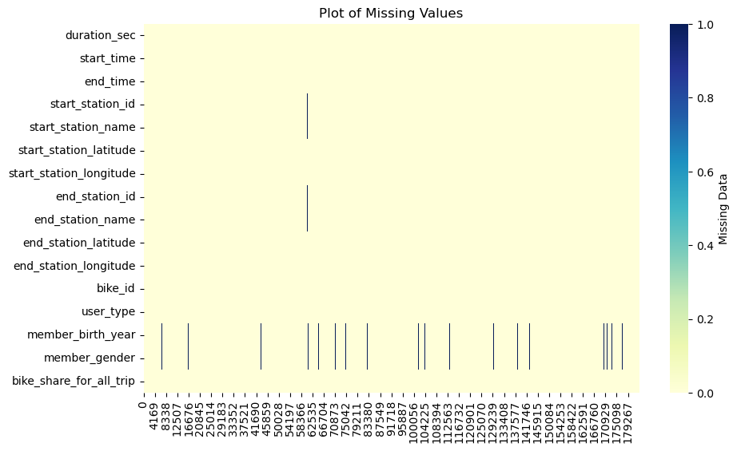

```python
plt.figure(figsize=(10,6))
plt.title('Plot of Missing Values')
missing_value_heatmap(data);
```

```python
# Drop Missing values
df = df.dropna()
```

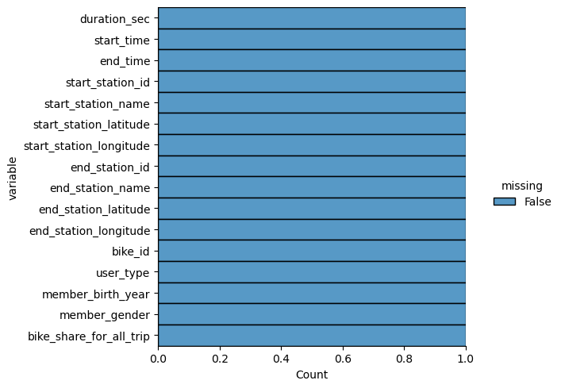

```python
# View results
plt.figure(figsize=(10,6))
sb.displot(
    data=df.isna().melt(value_name="missing"),
    y="variable",
    hue="missing",
    multiple="fill",
    aspect=1.25
)
```

##### ii.) Data type conversions

```python
#conversion of starttime and endtime to datetime
df['start_time'] = pd.to_datetime(df['start_time'])
df['end_time'] = pd.to_datetime(df['end_time'])

#convert member birth year from float to int64
df['member_birth_year'] =df['member_birth_year'].astype('int64')
```

```python
#checking for changes
df.dtypes
```

```
duration_sec                        int64
start_time                 datetime64[ns]
end_time                   datetime64[ns]
start_station_id                  float64
start_station_name                 object
start_station_latitude            float64
start_station_longitude           float64
end_station_id                    float64
end_station_name                   object
end_station_latitude              float64
end_station_longitude             float64
bike_id                             int64
user_type                          object
member_birth_year                   int64
member_gender                      object
bike_share_for_all_trip            object
dtype: object
```

```python
df.describe()
```

|  | duration_sec | start_station_id | start_station_latitude | start_station_longitude | end_station_id | end_station_latitude | end_station_longitude | bike_id | member_birth_year |
| --- | --- | --- | --- | --- | --- | --- | --- | --- | --- |
| count | 174952.000000 | 174952.000000 | 174952.000000 | 174952.000000 | 174952.000000 | 174952.000000 | 174952.000000 | 174952.000000 | 174952.000000 |
| mean | 704.002744 | 139.002126 | 37.771220 | -122.351760 | 136.604486 | 37.771414 | -122.351335 | 4482.587555 | 1984.803135 |
| std | 1642.204905 | 111.648819 | 0.100391 | 0.117732 | 111.335635 | 0.100295 | 0.117294 | 1659.195937 | 10.118731 |
| min | 61.000000 | 3.000000 | 37.317298 | -122.453704 | 3.000000 | 37.317298 | -122.453704 | 11.000000 | 1878.000000 |
| 25% | 323.000000 | 47.000000 | 37.770407 | -122.411901 | 44.000000 | 37.770407 | -122.411647 | 3799.000000 | 1980.000000 |
| 50% | 510.000000 | 104.000000 | 37.780760 | -122.398279 | 101.000000 | 37.781010 | -122.397437 | 4960.000000 | 1987.000000 |
| 75% | 789.000000 | 239.000000 | 37.797320 | -122.283093 | 238.000000 | 37.797673 | -122.286533 | 5505.000000 | 1992.000000 |
| max | 84548.000000 | 398.000000 | 37.880222 | -121.874119 | 398.000000 | 37.880222 | -121.874119 | 6645.000000 | 2001.000000 |

```python
df.head()
```

|  | duration_sec | start_time | end_time | start_station_id | start_station_name | start_station_latitude | start_station_longitude | end_station_id | end_station_name | end_station_latitude | end_station_longitude | bike_id | user_type | member_birth_year | member_gender | bike_share_for_all_trip |
| --- | --- | --- | --- | --- | --- | --- | --- | --- | --- | --- | --- | --- | --- | --- | --- | --- |
| 0 | 52185 | 2019-02-28 17:32:10.145 | 2019-03-01 08:01:55.975 | 21.0 | Montgomery St BART Station (Market St at 2nd St) | 37.789625 | -122.400811 | 13.0 | Commercial St at Montgomery St | 37.794231 | -122.402923 | 4902 | Customer | 1984 | Male | No |
| 2 | 61854 | 2019-02-28 12:13:13.218 | 2019-03-01 05:24:08.146 | 86.0 | Market St at Dolores St | 37.769305 | -122.426826 | 3.0 | Powell St BART Station (Market St at 4th St) | 37.786375 | -122.404904 | 5905 | Customer | 1972 | Male | No |
| 3 | 36490 | 2019-02-28 17:54:26.010 | 2019-03-01 04:02:36.842 | 375.0 | Grove St at Masonic Ave | 37.774836 | -122.446546 | 70.0 | Central Ave at Fell St | 37.773311 | -122.444293 | 6638 | Subscriber | 1989 | Other | No |
| 4 | 1585 | 2019-02-28 23:54:18.549 | 2019-03-01 00:20:44.074 | 7.0 | Frank H Ogawa Plaza | 37.804562 | -122.271738 | 222.0 | 10th Ave at E 15th St | 37.792714 | -122.248780 | 4898 | Subscriber | 1974 | Male | Yes |
| 5 | 1793 | 2019-02-28 23:49:58.632 | 2019-03-01 00:19:51.760 | 93.0 | 4th St at Mission Bay Blvd S | 37.770407 | -122.391198 | 323.0 | Broadway at Kearny | 37.798014 | -122.405950 | 5200 | Subscriber | 1959 | Male | No |

The Ford-GoBike dataset has 183412 records and 16 columns.

The main feature of interest in the dataset is `duration_sec`

### Feature Engineering

```python
# Convert the date time features and extract relevant sub features for analysis.

df['startDay'] = df['start_time'].dt.weekday
df['startMonth'] = df['start_time'].dt.month
df['Hour'] = pd.to_datetime(df['start_time']).dt.hour

df['endDay'] = df['end_time'].dt.weekday
df['endMonth'] = df['end_time'].dt.month

df['start_day_of_the_week'] = pd.to_datetime(df['start_time']).dt.day_name()
df['start_day_of_the_month'] = pd.to_datetime(df['start_time']).dt.date

df['end_day_of_the_week'] = pd.to_datetime(df['end_time']).dt.day_name()
df['end_day_of_the_month'] = pd.to_datetime(df['end_time']).dt.date
```

```python
df.describe(datetime_is_numeric=True)
```

|  | duration_sec | start_time | end_time | start_station_id | start_station_latitude | start_station_longitude | end_station_id | end_station_latitude | end_station_longitude | bike_id | member_birth_year | startDay | startMonth | Hour | endDay | endMonth |
| --- | --- | --- | --- | --- | --- | --- | --- | --- | --- | --- | --- | --- | --- | --- | --- | --- |
| count | 174952.000000 | 174952 | 174952 | 174952.000000 | 174952.000000 | 174952.000000 | 174952.000000 | 174952.000000 | 174952.000000 | 174952.000000 | 174952.000000 | 174952.000000 | 174952.0 | 174952.000000 | 174952.000000 | 174952.000000 |
| mean | 704.002744 | 2019-02-15 21:27:05.282492160 | 2019-02-15 21:38:49.784215040 | 139.002126 | 37.771220 | -122.351760 | 136.604486 | 37.771414 | -122.351335 | 4482.587555 | 1984.803135 | 2.619953 | 2.0 | 13.456165 | 2.620090 | 2.000080 |
| min | 61.000000 | 2019-02-01 00:00:20.636000 | 2019-02-01 00:04:52.058000 | 3.000000 | 37.317298 | -122.453704 | 3.000000 | 37.317298 | -122.453704 | 11.000000 | 1878.000000 | 0.000000 | 2.0 | 0.000000 | 0.000000 | 2.000000 |
| 25% | 323.000000 | 2019-02-08 08:32:16.954249984 | 2019-02-08 08:42:33.415500032 | 47.000000 | 37.770407 | -122.411901 | 44.000000 | 37.770407 | -122.411647 | 3799.000000 | 1980.000000 | 1.000000 | 2.0 | 9.000000 | 1.000000 | 2.000000 |
| 50% | 510.000000 | 2019-02-15 22:20:21.685499904 | 2019-02-15 22:33:41.234500096 | 104.000000 | 37.780760 | -122.398279 | 101.000000 | 37.781010 | -122.397437 | 4960.000000 | 1987.000000 | 3.000000 | 2.0 | 14.000000 | 3.000000 | 2.000000 |
| 75% | 789.000000 | 2019-02-22 11:22:05.289500160 | 2019-02-22 11:37:06.322249984 | 239.000000 | 37.797320 | -122.283093 | 238.000000 | 37.797673 | -122.286533 | 5505.000000 | 1992.000000 | 4.000000 | 2.0 | 17.000000 | 4.000000 | 2.000000 |
| max | 84548.000000 | 2019-02-28 23:59:18.548000 | 2019-03-01 08:01:55.975000 | 398.000000 | 37.880222 | -121.874119 | 398.000000 | 37.880222 | -121.874119 | 6645.000000 | 2001.000000 | 6.000000 | 2.0 | 23.000000 | 6.000000 | 3.000000 |
| std | 1642.204905 | NaN | NaN | 111.648819 | 0.100391 | 0.117732 | 111.335635 | 0.100295 | 0.117294 | 1659.195937 | 10.118731 | 1.808470 | 0.0 | 4.734282 | 1.808667 | 0.008945 |

```python
#Calculating the age. Current year is used is 2022
df['customer_age'] = 2019 - df['member_birth_year']
```

```python
# New Dataset Preview

df.head()
```

|  | duration_sec | start_time | end_time | start_station_id | start_station_name | start_station_latitude | start_station_longitude | end_station_id | end_station_name | end_station_latitude | ... | startDay | startMonth | Hour | endDay | endMonth | start_day_of_the_week | start_day_of_the_month | end_day_of_the_week | end_day_of_the_month | customer_age |
| --- | --- | --- | --- | --- | --- | --- | --- | --- | --- | --- | --- | --- | --- | --- | --- | --- | --- | --- | --- | --- | --- |
| 0 | 52185 | 2019-02-28 17:32:10.145 | 2019-03-01 08:01:55.975 | 21.0 | Montgomery St BART Station (Market St at 2nd St) | 37.789625 | -122.400811 | 13.0 | Commercial St at Montgomery St | 37.794231 | ... | 3 | 2 | 17 | 4 | 3 | Thursday | 2019-02-28 | Friday | 2019-03-01 | 35 |
| 2 | 61854 | 2019-02-28 12:13:13.218 | 2019-03-01 05:24:08.146 | 86.0 | Market St at Dolores St | 37.769305 | -122.426826 | 3.0 | Powell St BART Station (Market St at 4th St) | 37.786375 | ... | 3 | 2 | 12 | 4 | 3 | Thursday | 2019-02-28 | Friday | 2019-03-01 | 47 |
| 3 | 36490 | 2019-02-28 17:54:26.010 | 2019-03-01 04:02:36.842 | 375.0 | Grove St at Masonic Ave | 37.774836 | -122.446546 | 70.0 | Central Ave at Fell St | 37.773311 | ... | 3 | 2 | 17 | 4 | 3 | Thursday | 2019-02-28 | Friday | 2019-03-01 | 30 |
| 4 | 1585 | 2019-02-28 23:54:18.549 | 2019-03-01 00:20:44.074 | 7.0 | Frank H Ogawa Plaza | 37.804562 | -122.271738 | 222.0 | 10th Ave at E 15th St | 37.792714 | ... | 3 | 2 | 23 | 4 | 3 | Thursday | 2019-02-28 | Friday | 2019-03-01 | 45 |
| 5 | 1793 | 2019-02-28 23:49:58.632 | 2019-03-01 00:19:51.760 | 93.0 | 4th St at Mission Bay Blvd S | 37.770407 | -122.391198 | 323.0 | Broadway at Kearny | 37.798014 | ... | 3 | 2 | 23 | 4 | 3 | Thursday | 2019-02-28 | Friday | 2019-03-01 | 60 |

5 rows × 26 columns

```python
df.describe()
```

|  | duration_sec | start_station_id | start_station_latitude | start_station_longitude | end_station_id | end_station_latitude | end_station_longitude | bike_id | member_birth_year | startDay | startMonth | Hour | endDay | endMonth | customer_age |
| --- | --- | --- | --- | --- | --- | --- | --- | --- | --- | --- | --- | --- | --- | --- | --- |
| count | 174952.000000 | 174952.000000 | 174952.000000 | 174952.000000 | 174952.000000 | 174952.000000 | 174952.000000 | 174952.000000 | 174952.000000 | 174952.000000 | 174952.0 | 174952.000000 | 174952.000000 | 174952.000000 | 174952.000000 |
| mean | 704.002744 | 139.002126 | 37.771220 | -122.351760 | 136.604486 | 37.771414 | -122.351335 | 4482.587555 | 1984.803135 | 2.619953 | 2.0 | 13.456165 | 2.620090 | 2.000080 | 34.196865 |
| std | 1642.204905 | 111.648819 | 0.100391 | 0.117732 | 111.335635 | 0.100295 | 0.117294 | 1659.195937 | 10.118731 | 1.808470 | 0.0 | 4.734282 | 1.808667 | 0.008945 | 10.118731 |
| min | 61.000000 | 3.000000 | 37.317298 | -122.453704 | 3.000000 | 37.317298 | -122.453704 | 11.000000 | 1878.000000 | 0.000000 | 2.0 | 0.000000 | 0.000000 | 2.000000 | 18.000000 |
| 25% | 323.000000 | 47.000000 | 37.770407 | -122.411901 | 44.000000 | 37.770407 | -122.411647 | 3799.000000 | 1980.000000 | 1.000000 | 2.0 | 9.000000 | 1.000000 | 2.000000 | 27.000000 |
| 50% | 510.000000 | 104.000000 | 37.780760 | -122.398279 | 101.000000 | 37.781010 | -122.397437 | 4960.000000 | 1987.000000 | 3.000000 | 2.0 | 14.000000 | 3.000000 | 2.000000 | 32.000000 |
| 75% | 789.000000 | 239.000000 | 37.797320 | -122.283093 | 238.000000 | 37.797673 | -122.286533 | 5505.000000 | 1992.000000 | 4.000000 | 2.0 | 17.000000 | 4.000000 | 2.000000 | 39.000000 |
| max | 84548.000000 | 398.000000 | 37.880222 | -121.874119 | 398.000000 | 37.880222 | -121.874119 | 6645.000000 | 2001.000000 | 6.000000 | 2.0 | 23.000000 | 6.000000 | 3.000000 | 141.000000 |

```python
df.to_csv('df_clean.csv', index=False)
```

## Univariate Exploration

- Checking the distribution of individual variables.
  - Are there any unusual points?
  - Do they require any transformations?

Visualizing the target variable `duration_sec`

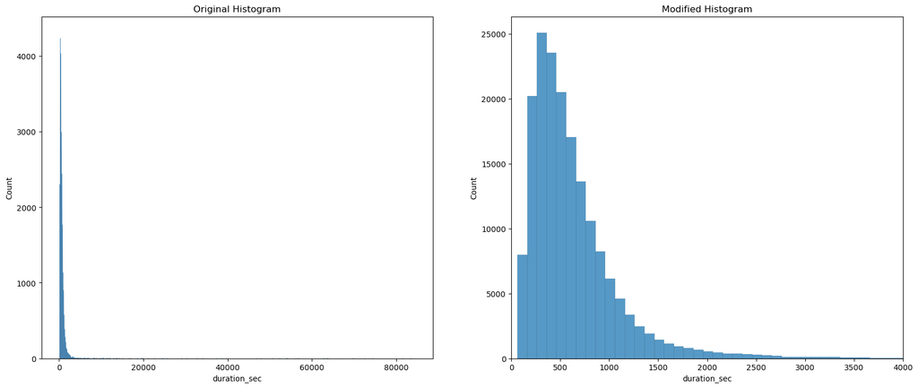

```python
plt.figure(figsize = [20, 8])

plt.subplot(1, 2, 1)
plt.title('Original Histogram')
sb.histplot(x = 'duration_sec', data=df)

plt.subplot(1, 2, 2)
bin_edges = np.arange(61, df['duration_sec'].max()+100, 100)
sb.histplot(df['duration_sec'], bins=bin_edges, kde=False)
plt.xlim((0,4000));
plt.title('Modified Histogram')
```

```python
df['duration_sec'].describe()
```

```
count    174952.000000
mean        704.002744
std        1642.204905
min          61.000000
25%         323.000000
50%         510.000000
75%         789.000000
max       84548.000000
Name: duration_sec, dtype: float64
```

The following observations were made from `duration_sec`

- It's highly skewed to the right and therefore needs a transformation
- It's unimodal

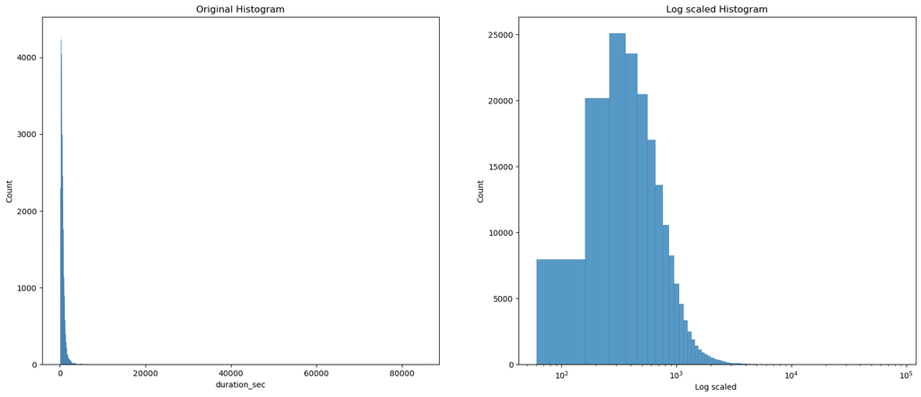

```python
plt.figure(figsize = [20, 8])

plt.subplot(1, 2, 1)
plt.title('Original Histogram')
sb.histplot(x = 'duration_sec', data=df)

plt.subplot(1, 2, 2)
bin_edges = np.arange(61, df['duration_sec'].max()+100, 100)
sb.histplot(df['duration_sec'], bins=bin_edges, kde=False)
plt.xscale('log')
plt.title('Log scaled Histogram')
plt.xlabel('Log scaled ');
```

```python
np.log10(df['duration_sec'].describe())
```

```
count    5.242919
mean     2.847574
std      3.215427
min      1.785330
25%      2.509203
50%      2.707570
75%      2.897077
max      4.927103
Name: duration_sec, dtype: float64
```

Log Transformation

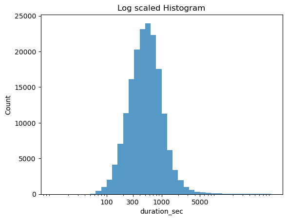

```python
bins = 10 ** np.arange(1, 5+0.1, 0.1)

ticks = [ 100, 300, 1000, 5000]
# Convert ticks into string values, to be displaye dlong the x-axis
labels = ['{}'.format(v) for v in ticks]

sb.histplot(df['duration_sec'], bins=bins, kde=False)
plt.xscale('log')
plt.title('Log scaled Histogram')


# Apply x-ticks
plt.xticks(ticks, labels);
```

After the transformation, the variable data is now normaly distributed.

```python
df.head()
```

|  | duration_sec | start_time | end_time | start_station_id | start_station_name | start_station_latitude | start_station_longitude | end_station_id | end_station_name | end_station_latitude | ... | startDay | startMonth | Hour | endDay | endMonth | start_day_of_the_week | start_day_of_the_month | end_day_of_the_week | end_day_of_the_month | customer_age |
| --- | --- | --- | --- | --- | --- | --- | --- | --- | --- | --- | --- | --- | --- | --- | --- | --- | --- | --- | --- | --- | --- |
| 0 | 52185 | 2019-02-28 17:32:10.145 | 2019-03-01 08:01:55.975 | 21.0 | Montgomery St BART Station (Market St at 2nd St) | 37.789625 | -122.400811 | 13.0 | Commercial St at Montgomery St | 37.794231 | ... | 3 | 2 | 17 | 4 | 3 | Thursday | 2019-02-28 | Friday | 2019-03-01 | 35 |
| 2 | 61854 | 2019-02-28 12:13:13.218 | 2019-03-01 05:24:08.146 | 86.0 | Market St at Dolores St | 37.769305 | -122.426826 | 3.0 | Powell St BART Station (Market St at 4th St) | 37.786375 | ... | 3 | 2 | 12 | 4 | 3 | Thursday | 2019-02-28 | Friday | 2019-03-01 | 47 |
| 3 | 36490 | 2019-02-28 17:54:26.010 | 2019-03-01 04:02:36.842 | 375.0 | Grove St at Masonic Ave | 37.774836 | -122.446546 | 70.0 | Central Ave at Fell St | 37.773311 | ... | 3 | 2 | 17 | 4 | 3 | Thursday | 2019-02-28 | Friday | 2019-03-01 | 30 |
| 4 | 1585 | 2019-02-28 23:54:18.549 | 2019-03-01 00:20:44.074 | 7.0 | Frank H Ogawa Plaza | 37.804562 | -122.271738 | 222.0 | 10th Ave at E 15th St | 37.792714 | ... | 3 | 2 | 23 | 4 | 3 | Thursday | 2019-02-28 | Friday | 2019-03-01 | 45 |
| 5 | 1793 | 2019-02-28 23:49:58.632 | 2019-03-01 00:19:51.760 | 93.0 | 4th St at Mission Bay Blvd S | 37.770407 | -122.391198 | 323.0 | Broadway at Kearny | 37.798014 | ... | 3 | 2 | 23 | 4 | 3 | Thursday | 2019-02-28 | Friday | 2019-03-01 | 60 |

5 rows × 26 columns

**Visualizing the `customer_age`**

- Is there any unusual observation?
- Is there any operation or transformation to adjust or better change the observations?

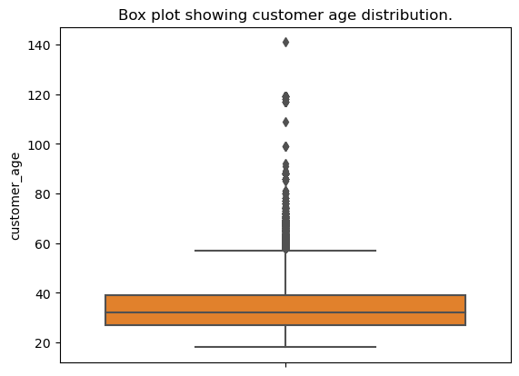

```python
def boxplot(df, age):
    base_color = sb.color_palette()[1]
    sb.boxplot(data = df, y = age, color = base_color)
    plt.title('Box plot showing customer age distribution.')
    plt.xticks(rotation = 15)
    plt.show()
boxplot(df,'customer_age')
```

The `customer_age` feature contains several outliers.

```python
df.customer_age.unique()
```

```
array([ 35,  47,  30,  45,  60,  36,  31,  27,  23,  26,  29,  38,  44,
        41,  28,  22,  33,  19,  37,  24,  39,  46,  34,  48,  40,  52,
        21,  25,  42,  20,  32,  50,  56,  43,  55,  54,  58,  51,  53,
        57,  65,  61,  59,  49,  63,  62,  74, 119,  67,  71,  68,  78,
        69,  70,  66,  64,  73,  72,  88,  76,  77,  99,  86,  18, 141,
       118,  75,  91,  85,  80,  89, 117, 109,  81,  92], dtype=int64)
```

```python
def remove_outliers(df, col):
    q1 = df[col].quantile(0.25)
    q3 = df[col].quantile(0.95)
    inter_quartile_range = q3-q1
    low  = q1 - 1.5 * inter_quartile_range
    high = q3 + 1.5 * inter_quartile_range
    new_df = df.loc[(df[col] > low) & (df[col] < high)]
    return new_df
```

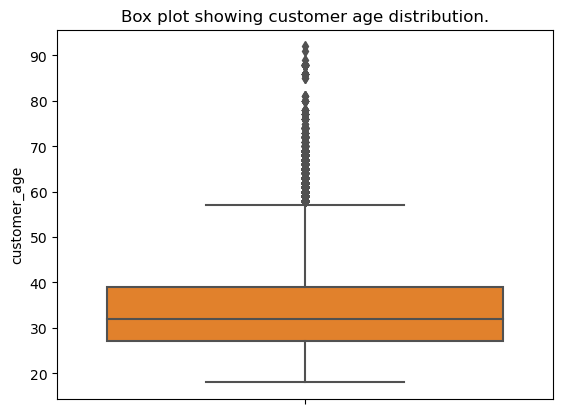

```python
df = remove_outliers(df,'customer_age')

boxplot(df, 'customer_age')
```

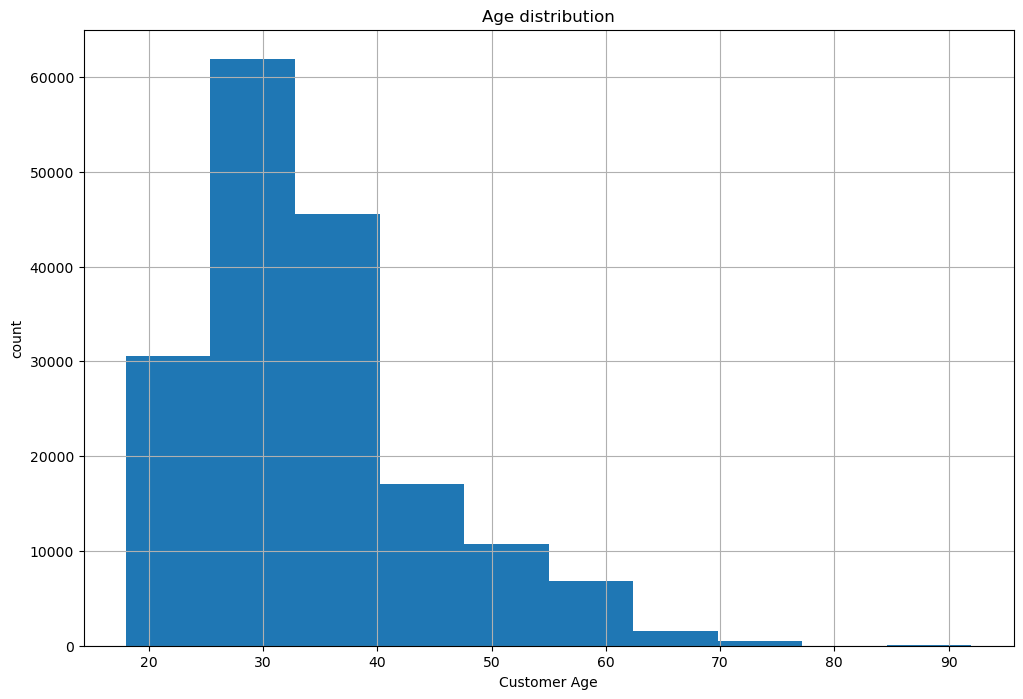

```python
plt.figure(figsize=(12,8))
df['customer_age'].hist()
plt.title('Age distribution')
plt.xlabel('Customer Age')
plt.ylabel('count');
```

### How many trips in a week?

**Visualizing the `start_day_of_the_week`**

```python
df['start_day_of_the_week'] = df['start_day_of_the_week'].astype('category')

df['start_day_of_the_week'].unique()
```

```
['Thursday', 'Wednesday', 'Tuesday', 'Monday', 'Sunday', 'Saturday', 'Friday']
Categories (7, object): ['Friday', 'Monday', 'Saturday', 'Sunday', 'Thursday', 'Tuesday', 'Wednesday']
```

```python
df['start_day_of_the_week'].value_counts().sort_values(ascending=False)
```

```
Thursday     33705
Tuesday      30567
Wednesday    28415
Friday       27645
Monday       25630
Sunday       14504
Saturday     14411
Name: start_day_of_the_week, dtype: int64
```

```python
def count_visualization(df,x,title,order_by):
    plt.figure(figsize=(10,8))
    sb.countplot(x=x, data=df, color=sb.color_palette()[0], order=order_by)
    plt.title(title)
    plt.xticks(rotation=90)
    plt.show()
```

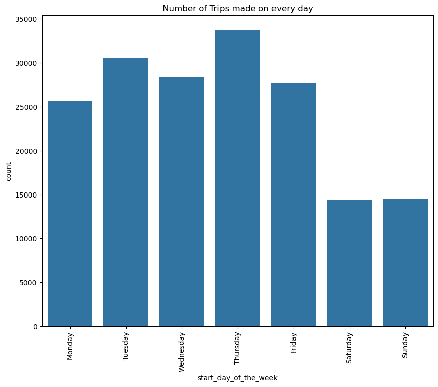

```python
CalendarDays = ['Monday','Tuesday','Wednesday','Thursday','Friday','Saturday','Sunday']


count_visualization(df,'start_day_of_the_week','Number of Trips made on every day',CalendarDays)
```

Generally most trips are made on weekdays with Thursday leading and a few on weekends.

### How many trips in a given hour?

**Visualizing `Hour`**

```python
# Count of rider records per hour

hourCount = df.groupby(['Hour']).size()
hourCount
```

```
Hour
0       893
1       525
2       355
3       164
4       227
5       866
6      3291
7     10226
8     20218
9     15196
10     7968
11     7460
12     8218
13     8093
14     7675
15     8642
16    13466
17    20896
18    16106
19     9418
20     6210
21     4399
22     2793
23     1572
dtype: int64
```

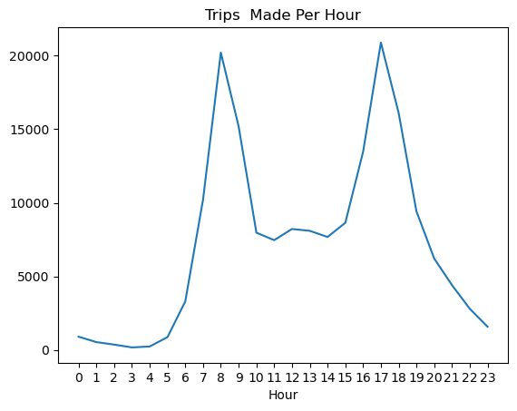

```python
#visualizing the trips made per hour

hourCount.plot()
plt.title('Trips  Made Per Hour')
plt.xticks(np.arange(0,24))
plt.show()
```

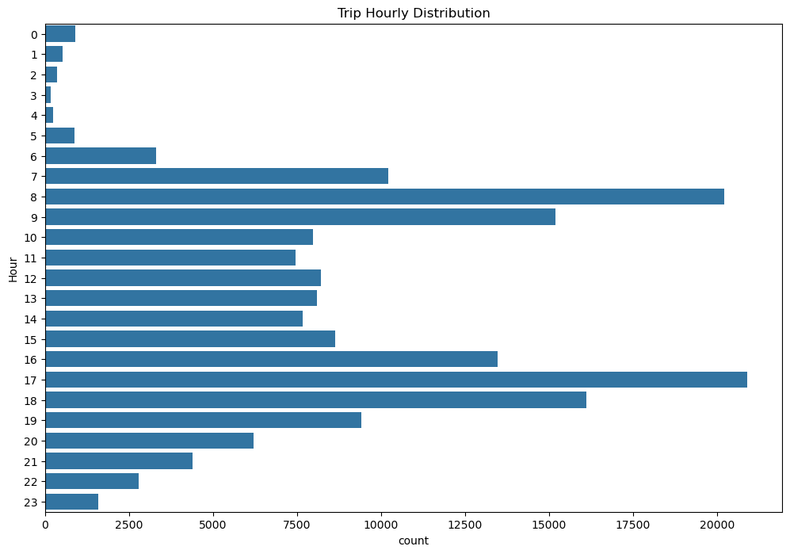

```python
plt.figure(figsize=(12,8))
base_color = sb.color_palette()[0]
sb.countplot( data = df , y = "Hour", color=base_color)
plt.title('Trip Hourly Distribution');
```

Most trips are made between 8am and 6pm

### How many trips in a month?

**`Month` Trip Reviews**

```python
# sorted_values = df['start_day_of_the_month'].sort_index(ascending=False).reset_index()['start_day_of_the_month']
# sorted_values
```

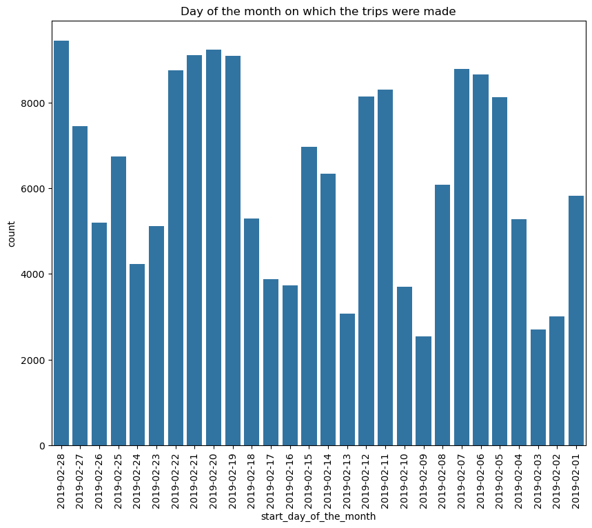

```python
# sorted_values = df['start_day_of_the_month'].sort_values(ascending=False)
count_visualization(df,'start_day_of_the_month','Day of the month on which the trips were made',None)
```

Most trips were made on 28th february and least on 9th february

### Which year were most riders born?

**`member_birth_year` of most riders**

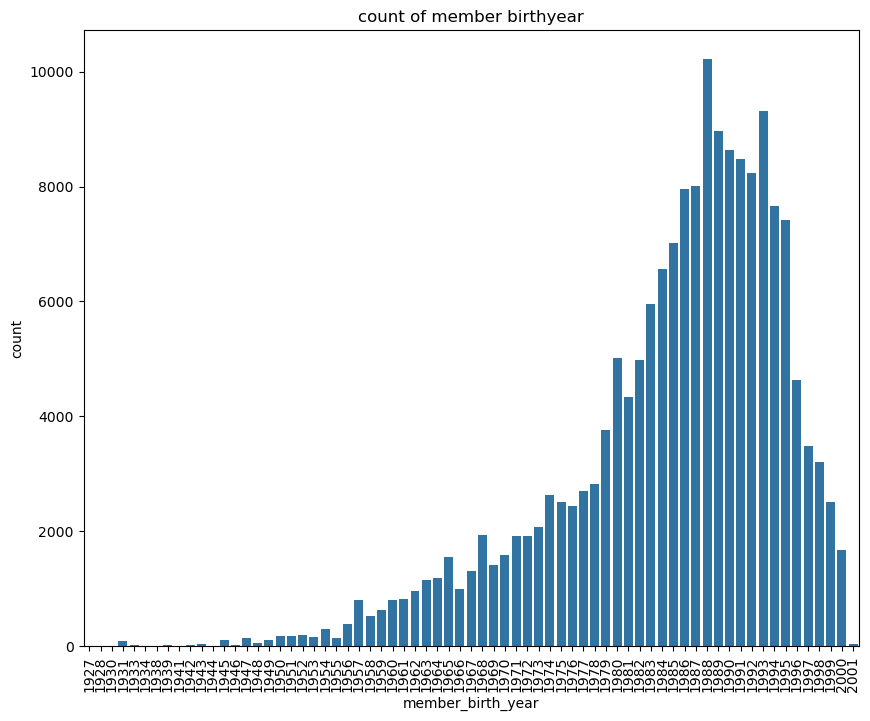

```python
#get the count of birth year using the function 'visualize_count'
count_visualization(df,'member_birth_year','count of member birthyear',None)
```

Most riders were born in 1988

### Are most riders males?

**Gender Distribution**

```python
def pie_plot(x_data, labels):
    plt.pie(x = x_data, labels = labels, startangle=0, counterclock= False,autopct='%1.1f%%')
    plt.axis('square')
```

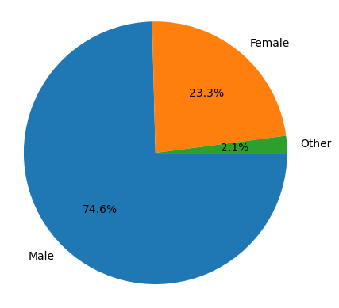

```python
gender = df['member_gender'].value_counts()
pie_plot(gender.values, gender.index)
```

### Are most riders subscribers or customers?

**User type Distribution**

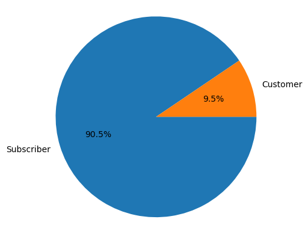

```python
user = df['user_type'].value_counts()
pie_plot(user.values, user.index)
```

Majority of bike riders were males.

Most bike rides were made by subscribers

**station review**

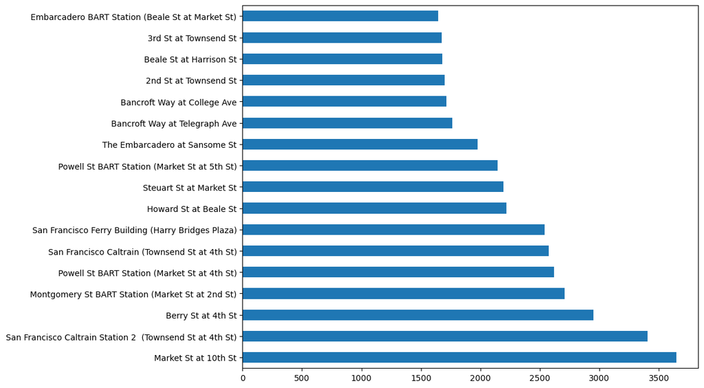

```python
# Visualizing top 10 stations
stations_count = df['start_station_name'].value_counts().iloc[lambda x: x.values > 1500]
stations_count.plot(kind='barh', figsize=(10,8))
```

> The `duration_sec` feature had a high right skew and I applied the log transformation to make it normal.

> The `Customer_age` feature had outliers that had to be removed.

> Removed Missing Values.

> Removed Outliers to remove unrealistic values from `customer_age`.

## Bivariate Exploration

The aim of the project Investigate how the duration of trips changes with respect to DateTime and customer type. Therefore the focus is first given to `duration_sec`, `user_type`

```python
# Categorical Variables

categorical_car = set(df.select_dtypes(exclude=['datetime64[ns]','int64','float64']).columns)
rem = {'start_day_of_the_month', 'end_day_of_the_month'}
categorical_car = categorical_car.difference(rem)

for var in categorical_car:
    df[var] = df[var].astype('category')
```

### How does trip duration vary with user type?

**Trip duration of `user_type`**

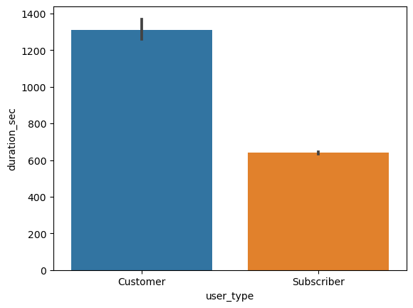

```python
#visualizing the distribution of trip duration by user Type
sb.barplot(x = 'user_type', y = 'duration_sec', data=df)
```

### How does rider age relate with time spent?

**`customer_age` and time spent**

[figure not shown]

```python
plt.figure(figsize=(10,6))
plt.title('Age vs Duration spent in hours')
plt.scatter(df['customer_age'], df['Hour'])
plt.xlabel('Customer Age')
plt.ylabel('Duration Spent (Hours)')
plt.show()
```

convert duration spent from seconds to hours for better visualization

```python
df['duration_hours'] = df['duration_sec']/3600
```

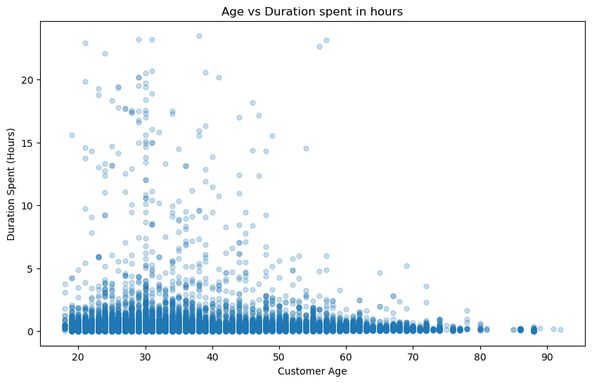

```python
plt.figure(figsize=(10,6))
plt.title('Age vs Duration spent in hours')
plt.scatter(df['customer_age'], df['duration_hours'], alpha=0.25, s=25)
plt.xlabel('Customer Age')
plt.ylabel('Duration Spent (Hours)')
plt.show()
```

Most young people between of approximately 20 and 45 years cycle for more hours than other ages

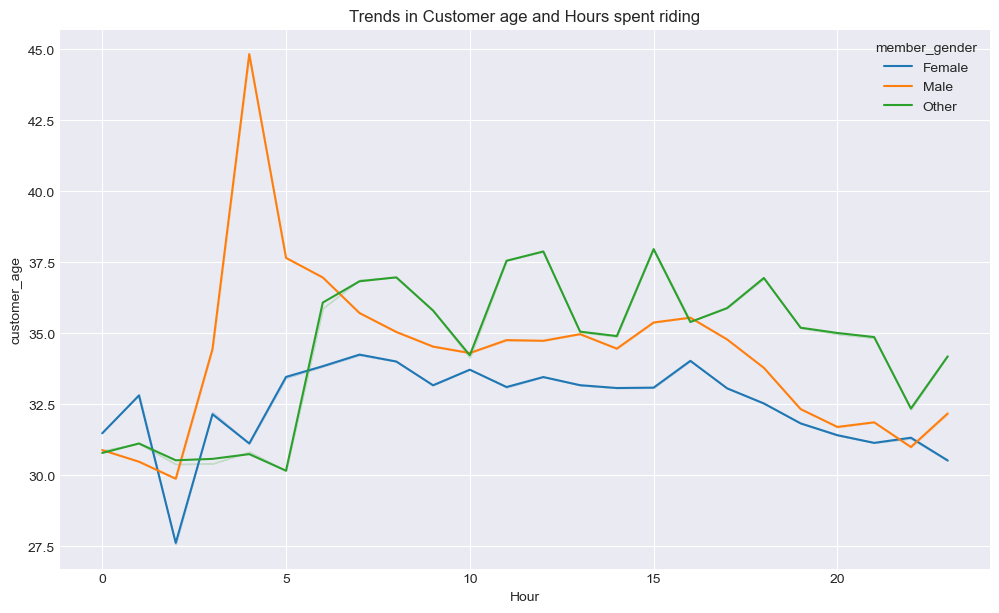

```python
plt.figure(figsize=(12,7))
sb.lineplot(x='Hour',y='customer_age',hue='member_gender',data=df, ci=False)
plt.title('Trends in Customer age and Hours spent riding')
plt.show()
```

### How long did daily trips last? What is the variability of trips made on weekdays over those made over the weekends?

**Checking for duration of trips made on weekdays vs those made on weekends**

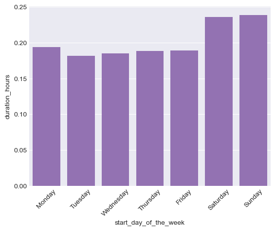

```python
sb.barplot(x = 'start_day_of_the_week', y = 'duration_hours', data=df , order=CalendarDays, color=sb.color_palette()[4], ci=None)
plt.xticks(rotation= 45)
plt.show();
```

Longest rides were on the weekend.

Longest weekday rides were on Monday

### What is the gender distribution of user types?

**Count of gender and 'user_type'**

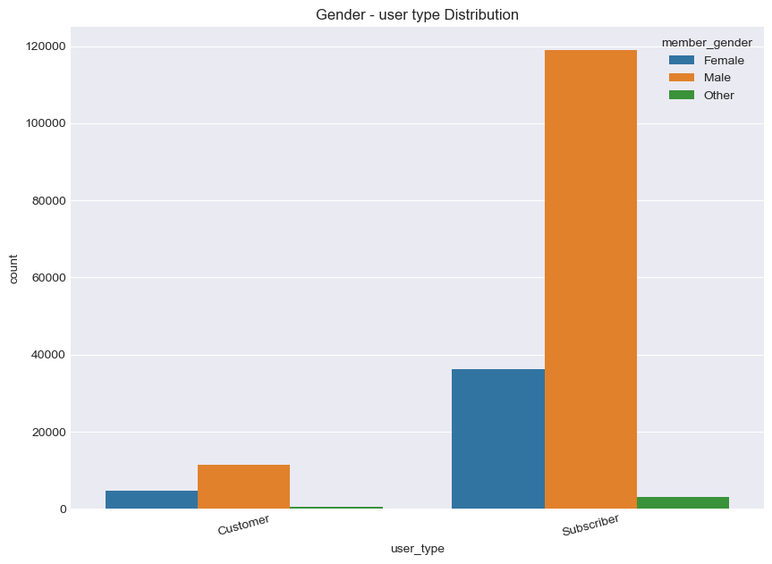

```python
plt.figure(figsize = (10,7))
sb.countplot(data=df, x= 'user_type', hue ='member_gender')
plt.title('Gender - user type Distribution')
plt.xticks(rotation=15);
```

More subscriber males are enrolled in biking

## Multivariate Exploration

### Is there any interesting interactions between gender, user type and age?

**User trip duration**

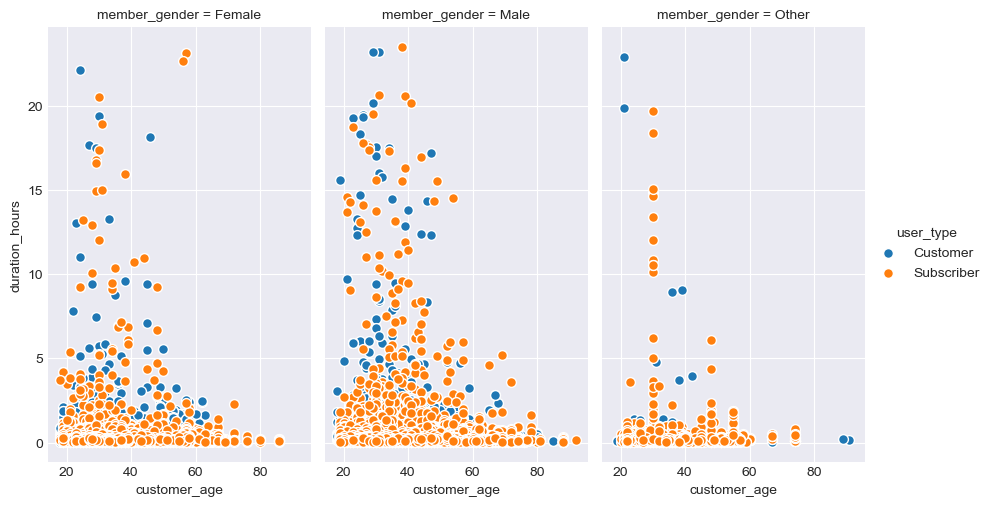

```python
g = sb.FacetGrid(df, col="member_gender" , hue="user_type" ,height=3, aspect=1)
g = g.map(plt.scatter, "customer_age" , "duration_hours" , edgecolor="w", s=50)
g.add_legend()
g.fig.set_size_inches(10,6);
```

There's a dense user concentration below 5hr mark

**`user_type` trip duration**

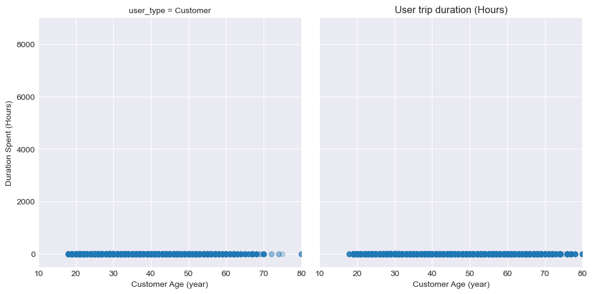

```python
user_types = sb.FacetGrid(data = df, \
                          col = 'user_type', col_wrap = 2, size = 5,\
                            xlim = [10, 80],
                            ylim = [-500, 9000])
user_types.map(plt.scatter, 'customer_age', 'duration_hours', alpha=0.25)
user_types.set_xlabels('Customer Age (year)')
user_types.set_ylabels('Duration Spent (Hours)')
plt.title('User trip duration (Hours)')
plt.show()
```

use `duration_sec` to get a better visualization

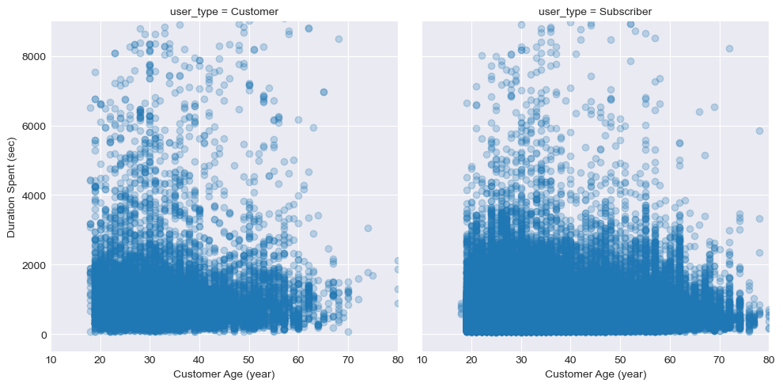

```python
user_types = sb.FacetGrid(data = df, \
                          col = 'user_type', col_wrap = 2, size = 5,\
                            xlim = [10, 80],
                            ylim = [-500, 9000])
user_types.map(plt.scatter, 'customer_age', 'duration_sec', alpha=0.25)
user_types.set_xlabels('Customer Age (year)')
user_types.set_ylabels('Duration Spent (sec)')

plt.show()
```

From the two visuals above, both the customer and subcriber show similar trend

**`user_type` distribution in comparison to 'customer_age' and `duration_sec` in `hours`**

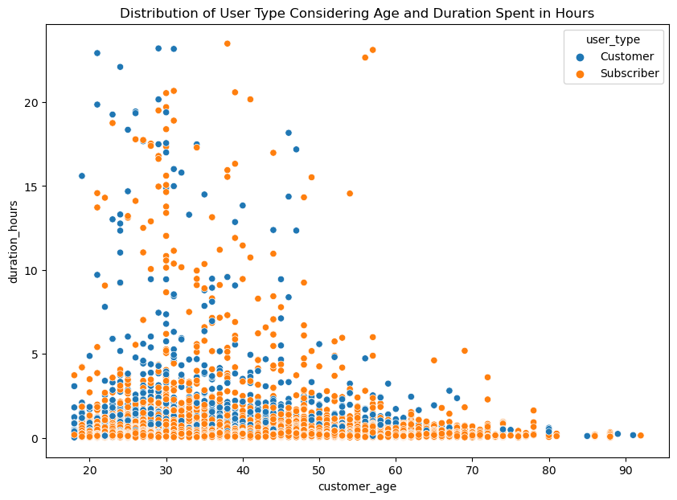

```python
plt.figure(figsize=(10,7))
sb.scatterplot(x= df['customer_age'], y=df['duration_hours'] , hue=df.user_type)
plt.title('Distribution of User Type Considering Age and Duration Spent in Hours')
plt.show()
```

From the distribution most users spend less than 5 hours biking.

## Conclusions

Most bike users are subscribers and most hiring is done between 8am and 5pm.

Majority of the bikers are males with age ranging from 20-40 years of age.